# Analysis of tree frog limb measurements

Sara Gama

2025-01-07

My GitHub repository is accessible here (https://github.com/SaraGama4/BIOL432_Assignment1_SG).

## 1: Loading files

Load required libraries

```r
library(dplyr)
```

```r
library(ggplot2)
library(tidyr)
```

I loaded the revised ‘measurements.csv’ file which now includes the ‘Volume’ column. I also loaded in my generated data and estimated volume scripts.

In the generated data script I chose five Canadian tree frog species and put them in a vector which I then randomly sampled from for a total of n= 100. I did the same process for generating three recorded names from observations. As for generating hypothetical values for limb width and lengths, I set plausible parameters for the normal distribution including a mean and standard deviation for both variables. This was followed by generating 100 random values from said normal distribution. Finally I combined all of the vectors to be separate columns in a csv file!

In the estimated volume script I read the csv file into a data frame and estimated limb volume using the formula for the volume of a cylinder (for biological relevance). I then mutated the values for each calculation into rows of a new column labelled “volume”.

```r
source("C:/Users/sgama/Downloads/432/BIOL432_Assignment1_SG/dataGenerato.R")
```

```
##   [1] "Hyla versicolor"     "Pseudacris regilla"  "Hyla chrysoscelis"
##   [4] "Hyla chrysoscelis"   "Hyla versicolor"     "Pseudacris regilla"
##   [7] "Pseudacris maculata" "Hyla versicolor"     "Acris crepitans"
##  [10] "Hyla versicolor"     "Acris crepitans"     "Pseudacris maculata"
##  [13] "Pseudacris maculata" "Hyla versicolor"     "Pseudacris maculata"
##  [16] "Hyla versicolor"     "Pseudacris regilla"  "Hyla chrysoscelis"
##  [19] "Acris crepitans"     "Acris crepitans"     "Pseudacris regilla"
##  [22] "Hyla versicolor"     "Acris crepitans"     "Pseudacris regilla"
##  [25] "Pseudacris maculata" "Hyla versicolor"     "Pseudacris maculata"
##  [28] "Pseudacris regilla"  "Acris crepitans"     "Hyla chrysoscelis"
##  [31] "Hyla versicolor"     "Hyla versicolor"     "Hyla versicolor"
##  [34] "Pseudacris regilla"  "Pseudacris maculata" "Pseudacris maculata"
##  [37] "Hyla versicolor"     "Pseudacris regilla"  "Pseudacris maculata"
##  [40] "Pseudacris regilla"  "Hyla versicolor"     "Hyla chrysoscelis"
##  [43] "Hyla versicolor"     "Hyla chrysoscelis"   "Pseudacris maculata"
```

[output cut: 150 more lines]

```r
source("C:/Users/sgama/Downloads/432/BIOL432_Assignment1_SG/volumeEstimato.R")
```

```
##          random_species  limb_width limb_length random_observer       Volume
## 1       Hyla versicolor 2.504421825    6.243680       Modernism 3.075711e+01
## 2    Pseudacris regilla 0.417774204    6.610564       Modernism 9.061741e-01
## 3     Hyla chrysoscelis 0.619476729    5.659189      Minimalism 1.705666e+00
## 4     Hyla chrysoscelis 2.736367925    6.297962       Modernism 3.703726e+01
## 5       Hyla versicolor 1.233766724    4.680477        Futurism 5.595593e+00
## 6    Pseudacris regilla 0.962226637    3.907899      Minimalism 2.841764e+00
## 7   Pseudacris maculata 3.560311059    5.245519      Minimalism 5.222209e+01
## 8       Hyla versicolor 0.009119462    5.842457      Minimalism 3.816136e-04
## 9       Acris crepitans 0.065228030    5.652824        Futurism 1.888965e-02
## 10      Hyla versicolor 0.779443565    5.257728       Modernism 2.508750e+00
## 11      Acris crepitans 1.988409507    5.373790       Modernism 1.668715e+01
## 12  Pseudacris maculata 1.071937138    5.465353        Futurism 4.932269e+00
## 13  Pseudacris maculata 1.989366902    6.657432        Futurism 2.069314e+01
## 14      Hyla versicolor 2.387739233    5.479266       Modernism 2.453500e+01
```

[output cut: 86 more lines]

```r
read.csv("C:/Users/sgama/Downloads/432/BIOL432_Assignment1_SG/measurements.csv")
```

```
##          random_species  limb_width limb_length random_observer       Volume
## 1       Hyla versicolor 2.504421825    6.243680       Modernism 3.075711e+01
## 2    Pseudacris regilla 0.417774204    6.610564       Modernism 9.061741e-01
## 3     Hyla chrysoscelis 0.619476729    5.659189      Minimalism 1.705666e+00
## 4     Hyla chrysoscelis 2.736367925    6.297962       Modernism 3.703726e+01
## 5       Hyla versicolor 1.233766724    4.680477        Futurism 5.595593e+00
## 6    Pseudacris regilla 0.962226637    3.907899      Minimalism 2.841764e+00
## 7   Pseudacris maculata 3.560311059    5.245519      Minimalism 5.222209e+01
## 8       Hyla versicolor 0.009119462    5.842457      Minimalism 3.816136e-04
## 9       Acris crepitans 0.065228030    5.652824        Futurism 1.888965e-02
## 10      Hyla versicolor 0.779443565    5.257728       Modernism 2.508750e+00
## 11      Acris crepitans 1.988409507    5.373790       Modernism 1.668715e+01
## 12  Pseudacris maculata 1.071937138    5.465353        Futurism 4.932269e+00
## 13  Pseudacris maculata 1.989366902    6.657432        Futurism 2.069314e+01
## 14      Hyla versicolor 2.387739233    5.479266       Modernism 2.453500e+01
```

[output cut: 86 more lines]

## 2: Sorting the data

I sorted the data first by species, then by observer, and by the limb volume using the arrange function

```r
sorted_df <- measurements_df %>%
  arrange(random_species, random_observer, Volume)

head(sorted_df)
```

```
##    random_species limb_width limb_length random_observer      Volume
## 1 Acris crepitans 0.06522803    5.652824        Futurism  0.01888965
## 2 Acris crepitans 0.76031033    6.128030        Futurism  2.78222690
## 3 Acris crepitans 2.28226377    5.076272        Futurism 20.76665017
## 4 Acris crepitans 2.25249650    5.487488        Futurism 21.86712559
## 5 Acris crepitans 0.50082005    6.103513      Minimalism  1.20235628
## 6 Acris crepitans 1.14560139    6.819742      Minimalism  7.02950724
```

## 3: Calculating averages for a variable of interest

I calculated the average limb volume for each species in a table

```r
avg_vol_species <- measurements_df %>%
  group_by(random_species) %>%
  summarize(avg_vol = mean(Volume, na.rm = TRUE))

avg_vol_species
```

```
## # A tibble: 5 × 2
##   random_species      avg_vol
##   <chr>                 <dbl>
## 1 Acris crepitans        15.9
## 2 Hyla chrysoscelis      16.3
## 3 Hyla versicolor        14.9
## 4 Pseudacris maculata    10.9
## 5 Pseudacris regilla     18.2
```

## 4: Counting the number of observations occurring in two variables

I made a table for the number of observations (rows) for each combination of species and observer.

```r
obs_species_observer <- measurements_df %>%
  group_by(random_species, random_observer) %>%
  summarise(num_obs = n())
obs_species_observer
```

```
## # A tibble: 15 × 3
## # Groups:   random_species [5]
##    random_species      random_observer num_obs
##    <chr>               <chr>             <int>
##  1 Acris crepitans     Futurism              4
##  2 Acris crepitans     Minimalism            6
##  3 Acris crepitans     Modernism             5
##  4 Hyla chrysoscelis   Futurism              7
##  5 Hyla chrysoscelis   Minimalism            8
##  6 Hyla chrysoscelis   Modernism             3
##  7 Hyla versicolor     Futurism              9
##  8 Hyla versicolor     Minimalism            4
##  9 Hyla versicolor     Modernism            12
## 10 Pseudacris maculata Futurism             11
## 11 Pseudacris maculata Minimalism            7
## 12 Pseudacris maculata Modernism             8
## 13 Pseudacris regilla  Futurism              4
## 14 Pseudacris regilla  Minimalism            5
## 15 Pseudacris regilla  Modernism             7
```

## 5: Visualizing tree frog limb volume distributions

I created a box plot comparing limb volumes for each species

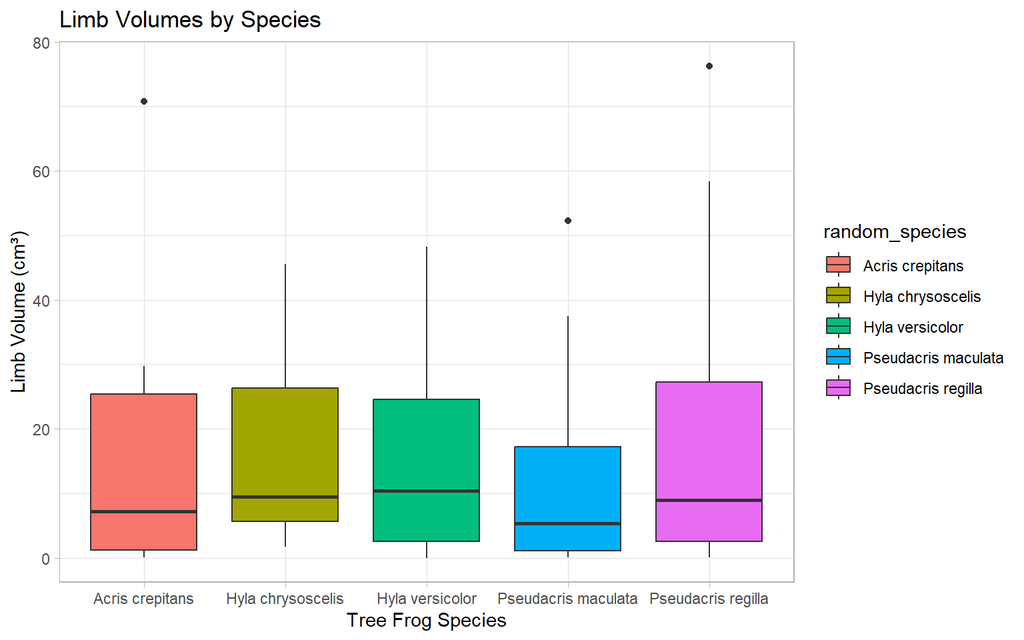

```r
ggplot(measurements_df, aes(x = random_species, y = Volume)) +
  geom_boxplot(aes(fill = random_species)) +
  labs(title = "Limb Volumes by Species",
       x = "Tree Frog Species",
       y = "Limb Volume (cm³)") +
  theme_light()
```

## 6: Visualizing distributions of limb volumes in a histogram

I created a multi-panel plot of frequency histograms by species

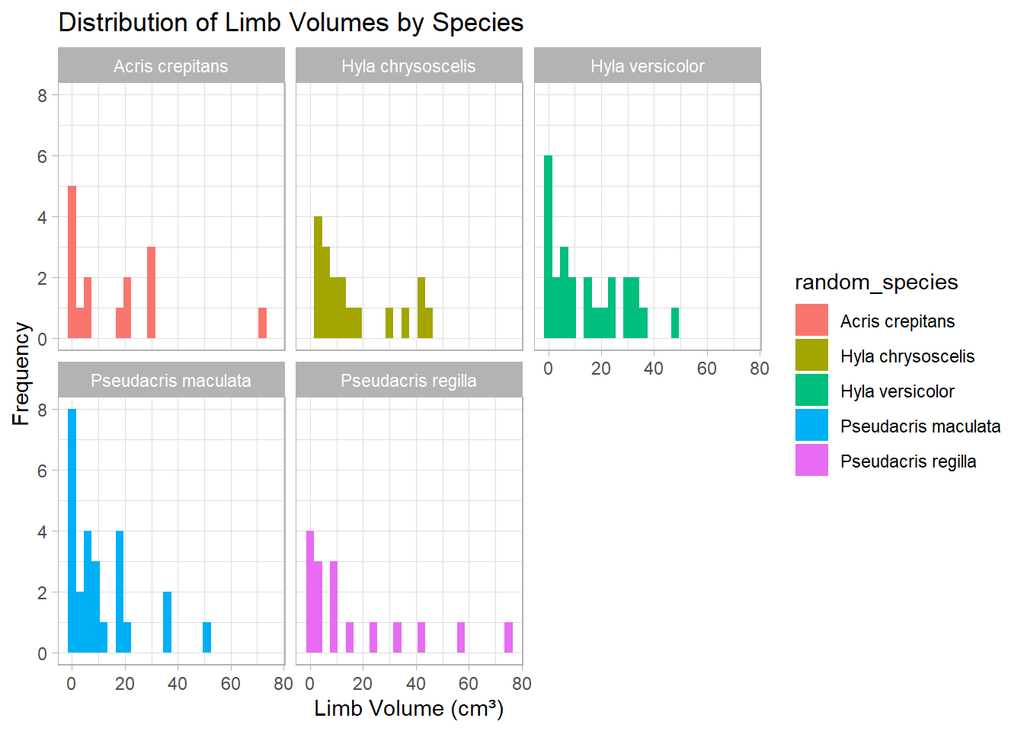

```r
ggplot(measurements_df, aes(x = Volume)) +
  geom_histogram(aes(fill = random_species),binwidth = 3) +
  facet_wrap(~random_species) +
  labs(title = "Distribution of Limb Volumes by Species",
       x = "Limb Volume (cm³)",
       y = "Frequency") +
  theme_light()
```